# ExtraaLearn Project

## Context

The EdTech industry has been surging in the past decade immensely, and according to a forecast, the Online Education market would be worth $286.62bn by 2023 with a compound annual growth rate (CAGR) of 10.26% from 2018 to 2023. The modern era of online education has enforced a lot in its growth and expansion beyond any limit. Due to having many dominant features like ease of information sharing, personalized learning experience, transparency of assessment, etc, it is now preferable to traditional education.

In the present scenario due to the Covid-19, the online education sector has witnessed rapid growth and is attracting a lot of new customers. Due to this rapid growth, many new companies have emerged in this industry. With the availability and ease of use of digital marketing resources, companies can reach out to a wider audience with their offerings. The customers who show interest in these offerings are termed as leads. There are various sources of obtaining leads for Edtech companies, like

- The customer interacts with the marketing front on social media or other online platforms.
- The customer browses the website/app and downloads the brochure
- The customer connects through emails for more information.

The company then nurtures these leads and tries to convert them to paid customers. For this, the representative from the organization connects with the lead on call or through email to share further details.

## Objective

ExtraaLearn is an initial stage startup that offers programs on cutting-edge technologies to students and professionals to help them upskill/reskill. With a large number of leads being generated on a regular basis, one of the issues faced by ExtraaLearn is to identify which of the leads are more likely to convert so that they can allocate resources accordingly. You, as a data scientist at ExtraaLearn, have been provided the leads data to:

- Analyze and build an ML model to help identify which leads are more likely to convert to paid customers,
- Find the factors driving the lead conversion process
- Create a profile of the leads which are likely to convert

## Data Description

The data contains the different attributes of leads and their interaction details with ExtraaLearn. The detailed data dictionary is given below.

**Data Dictionary**

- ID: ID of the lead
- age: Age of the lead
- current_occupation: Current occupation of the lead. Values include 'Professional','Unemployed',and 'Student'
- first_interaction: How did the lead first interacted with ExtraaLearn. Values include 'Website', 'Mobile App'
- profile_completed: What percentage of profile has been filled by the lead on the website/mobile app. Values include Low - (0-50%), Medium - (50-75%), High (75-100%)
- website_visits: How many times has a lead visited the website
- time_spent_on_website: Total time spent on the website
- page_views_per_visit: Average number of pages on the website viewed during the visits.
- last_activity: Last interaction between the lead and ExtraaLearn.
  - Email Activity: Seeking for details about program through email, Representative shared information with lead like brochure of program , etc
  - Phone Activity: Had a Phone Conversation with representative, Had conversation over SMS with representative, etc
  - Website Activity: Interacted on live chat with representative, Updated profile on website, etc
- print_media_type1: Flag indicating whether the lead had seen the ad of ExtraaLearn in the Newspaper.
- print_media_type2: Flag indicating whether the lead had seen the ad of ExtraaLearn in the Magazine.
- digital_media: Flag indicating whether the lead had seen the ad of ExtraaLearn on the digital platforms.
- educational_channels: Flag indicating whether the lead had heard about ExtraaLearn in the education channels like online forums, discussion threads, educational websites, etc.
- referral: Flag indicating whether the lead had heard about ExtraaLearn through reference.
- status: Flag indicating whether the lead was converted to a paid customer or not.

## Importing necessary libraries and data

```python
#Importing necessary Python libraries
import pandas as pd
import numpy as np
import matplotlib.pyplot as plt
import seaborn as sns
import warnings
warnings.filterwarnings('ignore')


# importing libraries  build models for prediction
from sklearn.model_selection import train_test_split, cross_val_score, KFold
from sklearn.preprocessing import StandardScaler
from sklearn.tree import DecisionTreeClassifier, plot_tree
from sklearn.ensemble import RandomForestClassifier

#import library to measure model performance
from sklearn.metrics import confusion_matrix, classification_report,recall_score,precision_score, accuracy_score,f1_score

# For tuning the model
from sklearn.model_selection import GridSearchCV

#set display parameters
# Removes the limit for the number of displayed columns
pd.set_option("display.max_columns", None)

# Sets the limit for the number of displayed rows
pd.set_option("display.max_rows", 200)
```

```python
from google.colab import drive
drive.mount('/content/drive')
```

```python
# Read the ExtraaLearn dataset file
data = pd.read_csv("/content/drive/My Drive/GL_MIT_ADSP/Week_8_ElectiveProject/data/ExtraaLearn.csv")
```

## Data Overview

- Observations
- Sanity checks

```python
#Create copy of the dataset
data_copy = data.copy()
```

```python
#check # of rows and colums
data.shape
```

```
(4612, 15)
```

```python
# check the data layout
data.info()
```

```
<class 'pandas.core.frame.DataFrame'>
RangeIndex: 4612 entries, 0 to 4611
Data columns (total 15 columns):
 #   Column                 Non-Null Count  Dtype
---  ------                 --------------  -----
 0   ID                     4612 non-null   object
 1   age                    4612 non-null   int64
 2   current_occupation     4612 non-null   object
 3   first_interaction      4612 non-null   object
 4   profile_completed      4612 non-null   object
 5   website_visits         4612 non-null   int64
 6   time_spent_on_website  4612 non-null   int64
 7   page_views_per_visit   4612 non-null   float64
 8   last_activity          4612 non-null   object
 9   print_media_type1      4612 non-null   object
 10  print_media_type2      4612 non-null   object
 11  digital_media          4612 non-null   object
 12  educational_channels   4612 non-null   object
 13  referral               4612 non-null   object
 14  status                 4612 non-null   int64
dtypes: float64(1), int64(4), object(10)
memory usage: 540.6+ KB
```

```python
data.head(5)
```

|  | ID | age | current_occupation | first_interaction | profile_completed | website_visits | time_spent_on_website | page_views_per_visit | last_activity | print_media_type1 | print_media_type2 | digital_media | educational_channels | referral | status |
| --- | --- | --- | --- | --- | --- | --- | --- | --- | --- | --- | --- | --- | --- | --- | --- |
| 0 | EXT001 | 57 | Unemployed | Website | High | 7 | 1639 | 1.861 | Website Activity | Yes | No | Yes | No | No | 1 |
| 1 | EXT002 | 56 | Professional | Mobile App | Medium | 2 | 83 | 0.320 | Website Activity | No | No | No | Yes | No | 0 |
| 2 | EXT003 | 52 | Professional | Website | Medium | 3 | 330 | 0.074 | Website Activity | No | No | Yes | No | No | 0 |
| 3 | EXT004 | 53 | Unemployed | Website | High | 4 | 464 | 2.057 | Website Activity | No | No | No | No | No | 1 |
| 4 | EXT005 | 23 | Student | Website | High | 4 | 600 | 16.914 | Email Activity | No | No | No | No | No | 0 |

```python
# check # of duplicates
data.duplicated().sum()
```

```
np.int64(0)
```

```python
#check unique ID
data.nunique()
```

|  | 0 |
| --- | --- |
| ID | 4612 |
| age | 46 |
| current_occupation | 3 |
| first_interaction | 2 |
| profile_completed | 3 |
| website_visits | 27 |
| time_spent_on_website | 1623 |
| page_views_per_visit | 2414 |
| last_activity | 3 |
| print_media_type1 | 2 |
| print_media_type2 | 2 |
| digital_media | 2 |
| educational_channels | 2 |
| referral | 2 |
| status | 2 |

**dtype:** int64

```python
data.isna().sum()
```

|  | 0 |
| --- | --- |
| ID | 0 |
| age | 0 |
| current_occupation | 0 |
| first_interaction | 0 |
| profile_completed | 0 |
| website_visits | 0 |
| time_spent_on_website | 0 |
| page_views_per_visit | 0 |
| last_activity | 0 |
| print_media_type1 | 0 |
| print_media_type2 | 0 |
| digital_media | 0 |
| educational_channels | 0 |
| referral | 0 |
| status | 0 |

**dtype:** int64

**Observation**

**The dataset has 4,612 observations and 15 columns.**

The data consists of 10 categorical variables and 5 numeric variables.None of variables have missing values.

There are **no duplicates and no missing values** in the datasets

'ID' is unqiue key and can be dropped from further analysis

**Creating list of numerical and Categorical variables for EDA.**

```python
# extract the categorical variables from the dataset
cat_col =data.select_dtypes(include='object').columns
# drop the ID column from the cat_col list
cat_col=cat_col.drop('ID')
print(cat_col.to_list())
# extract numerical variables from the dataset
num_col = data.select_dtypes(exclude='object').columns
# drop the status column as it binary variable and target variable
num_col = num_col.drop('status')
print(num_col.to_list())
```

```
['current_occupation', 'first_interaction', 'profile_completed', 'last_activity', 'print_media_type1', 'print_media_type2', 'digital_media', 'educational_channels', 'referral']
['age', 'website_visits', 'time_spent_on_website', 'page_views_per_visit']
```

## Exploratory Data Analysis (EDA)

- EDA is an important part of any project involving data.
- It is important to investigate and understand the data better before building a model with it.
- A few questions have been mentioned below which will help you approach the analysis in the right manner and generate insights from the data.
- A thorough analysis of the data, in addition to the questions mentioned below, should be done.

**Questions**

1. Leads will have different expectations from the outcome of the course and the current occupation may play a key role in getting them to participate in the program. Find out how current occupation affects lead status.
2. The company's first impression on the customer must have an impact. Do the first channels of interaction have an impact on the lead status?
3. The company uses multiple modes to interact with prospects. Which way of interaction works best?
4. The company gets leads from various channels such as print media, digital media, referrals, etc. Which of these channels have the highest lead conversion rate?
5. People browsing the website or mobile application are generally required to create a profile by sharing their personal data before they can access additional information.Does having more details about a prospect increase the chances of conversion?

**Univariate analysis of numerical columns**

```python
# Check the missings and distribution
data.describe().T
```

|  | count | mean | std | min | 25% | 50% | 75% | max |
| --- | --- | --- | --- | --- | --- | --- | --- | --- |
| age | 4612.0 | 46.201214 | 13.161454 | 18.0 | 36.00000 | 51.000 | 57.00000 | 63.000 |
| website_visits | 4612.0 | 3.566782 | 2.829134 | 0.0 | 2.00000 | 3.000 | 5.00000 | 30.000 |
| time_spent_on_website | 4612.0 | 724.011275 | 743.828683 | 0.0 | 148.75000 | 376.000 | 1336.75000 | 2537.000 |
| page_views_per_visit | 4612.0 | 3.026126 | 1.968125 | 0.0 | 2.07775 | 2.792 | 3.75625 | 18.434 |
| status | 4612.0 | 0.298569 | 0.457680 | 0.0 | 0.00000 | 0.000 | 1.00000 | 1.000 |

**Observation**

```
array([[<Axes: title={'center': 'age'}>,
        <Axes: title={'center': 'website_visits'}>],
       [<Axes: title={'center': 'time_spent_on_website'}>,
        <Axes: title={'center': 'page_views_per_visit'}>]], dtype=object)
```

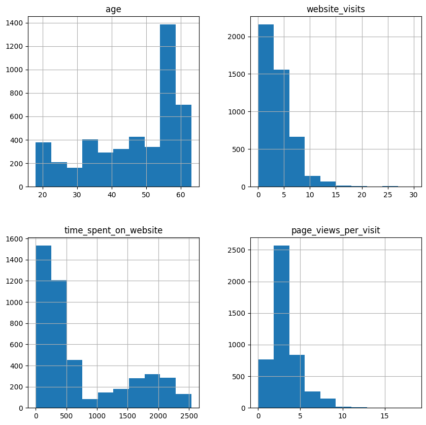

```python
data[num_col].hist(figsize=(10,10))
```

|  | 0 |
| --- | --- |
| age | Axes(0.125,0.653529;0.352273x0.226471) |
| website_visits | Axes(0.547727,0.653529;0.352273x0.226471) |
| time_spent_on_website | Axes(0.125,0.381765;0.352273x0.226471) |
| page_views_per_visit | Axes(0.547727,0.381765;0.352273x0.226471) |

**dtype:** object

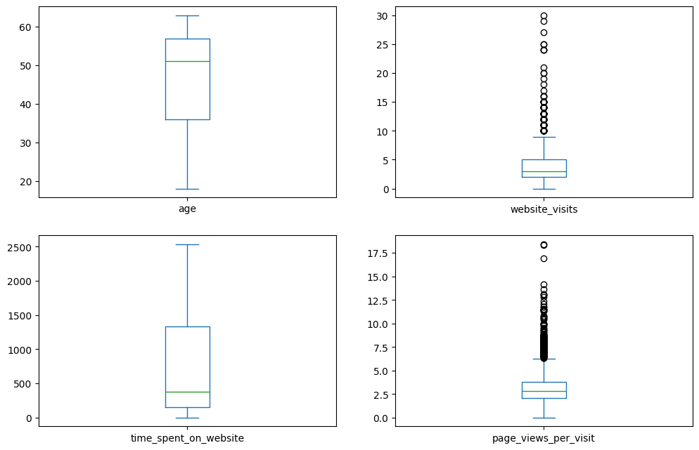

```python
data[num_col].plot(kind='box',subplots=True,layout=(3,2),figsize=(12,12))
```

**Observation:**

- The customer **age is slightly left skewed**, **median Age is ~50 years and average age is 46 years.**
- The distribution of visits to the website is right skewed. On average, customer leads visit the ExtraaLearn website 3 times There are very few leads visiting the website more than 10 times.
- **50% of the leads spend around less than 500 seconds ( or less than 9 minutes) on the website.** The distribution is right skewed
- Pages per view is right skewed distribution. **On average, lead views around 3 pages per visit.** There are very few leads visiting more than 7 pages per visit.

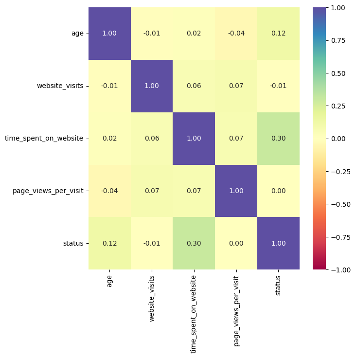

```python
plt.figure(figsize=(7,7))
sns.heatmap(data.corr(numeric_only = True), annot = True, vmin = -1, vmax = 1, fmt = ".2f", cmap = "Spectral")
```

**Observation**

**None of numeric features are strongly correlated with lead conversion to paid customer(status).** The highest correlation between time spent on the website and conversion to paid customer is at 30%(weak)

```python
 data.groupby(['status'])['ID'].count()/data.shape[0]*100
```

| status | ID |
| --- | --- |
| 0 | 70.143105 |
| 1 | 29.856895 |

**dtype:** float64

**Observation** The conversion rate from customer leads to paid accounts is 30%.

**Univariate analysis of Categorical variables**

```python
for i in cat_col:
    print(data[i].value_counts(normalize = True))

    print('*' * 40)
```

```
current_occupation
Professional    0.567216
Unemployed      0.312446
Student         0.120338
Name: proportion, dtype: float64
first_interaction
Website       0.551171
Mobile App    0.448829
Name: proportion, dtype: float64
profile_completed
High      0.490893
Medium    0.485906
Low       0.023200
Name: proportion, dtype: float64
last_activity
Email Activity      0.493929
Phone Activity      0.267563
Website Activity    0.238508
Name: proportion, dtype: float64
print_media_type1
No     0.892238
Yes    0.107762
Name: proportion, dtype: float64
print_media_type2
No     0.94948
Yes    0.05052
Name: proportion, dtype: float64
digital_media
No     0.885733
Yes    0.114267
Name: proportion, dtype: float64
educational_channels
No     0.847138
Yes    0.152862
Name: proportion, dtype: float64
referral
No     0.979835
Yes    0.020165
Name: proportion, dtype: float64
```

**Observations**

**Bivariate and Multivariate Analysis**

```python
 data.groupby(['status'])[num_col].mean()
```

| status | age | website_visits | time_spent_on_website | page_views_per_visit |
| --- | --- | --- | --- | --- |
| 0 | 45.153014 | 3.578980 | 577.420711 | 3.025732 |
| 1 | 48.663762 | 3.538126 | 1068.397967 | 3.027050 |

**Observations**

- The average for website visits and page viewed per is visit has very similar for customer lead who convert to paid customer or those who do not convert
- The customer converting paid members spend ~2 times higher time on the website as compared to those who do not.

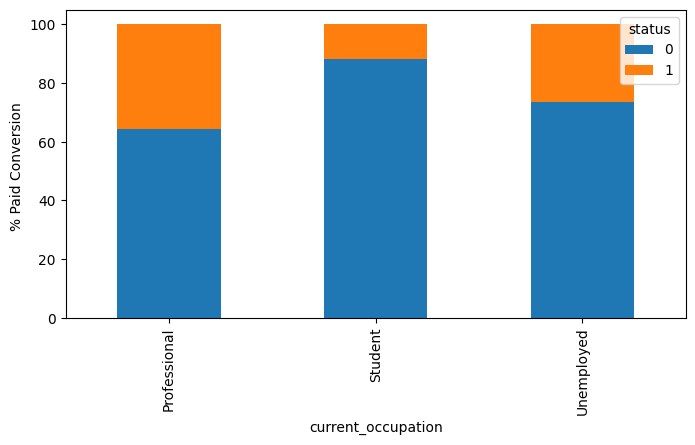

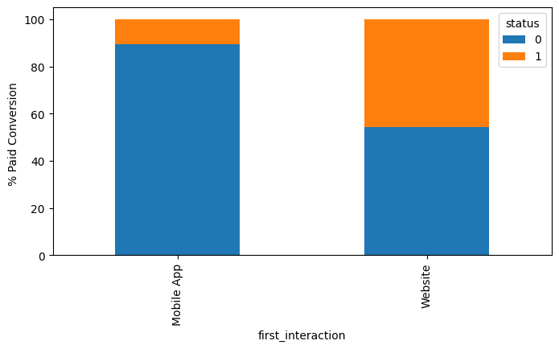

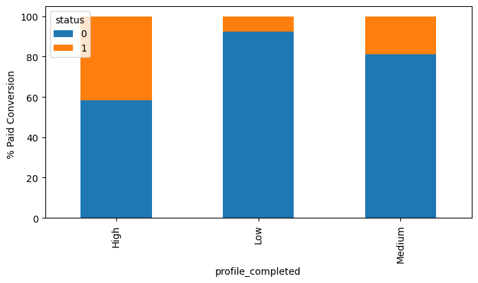

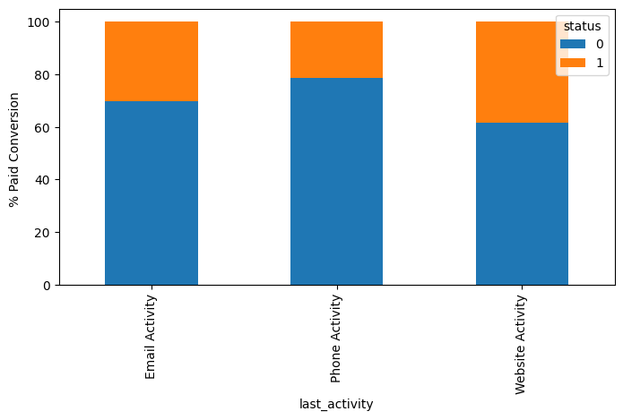

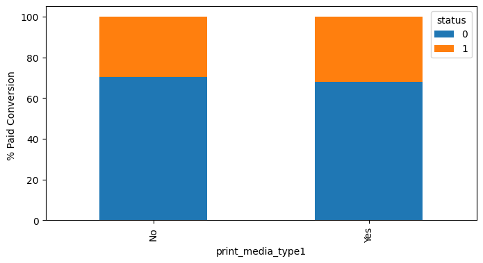

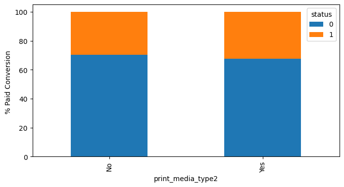

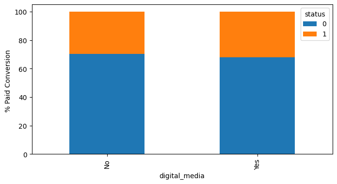

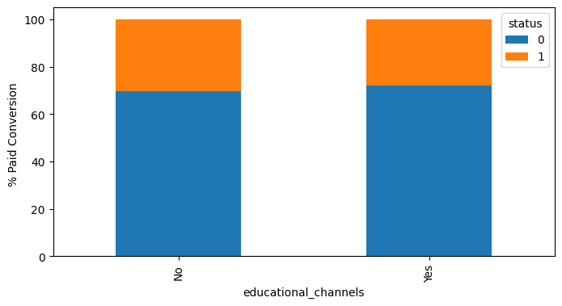

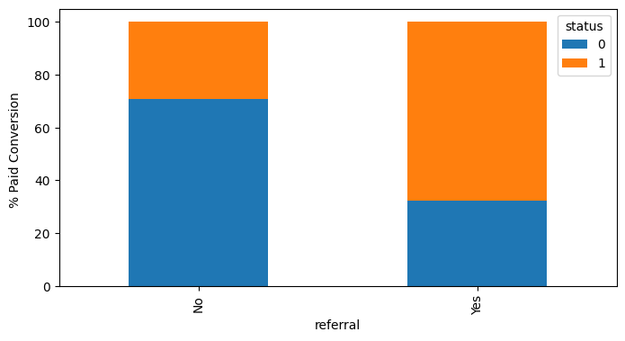

```python
for i in cat_col:
       (pd.crosstab(data[i], data['status'], normalize = 'index')*100).plot(kind = 'bar', figsize = (8, 4), stacked = True)
       plt.ylabel('% Paid Conversion ')
```

**Observation**

## Data Preprocessing

- Missing value treatment (if needed)
- Feature engineering (if needed)
- Outlier detection and treatment (if needed)
- Preparing data for modeling
- Any other preprocessing steps (if needed)

**Preparing data for modeling**

- Creating new feature and creating dummy variables for categorical variables

```python
# separate categorical variables which have Yes/No values
cat_col_1 = cat_col[4:]
# separate categorical variables with muiltiple categories
cat_col_2 = cat_col[:4]
cat_col_1,cat_col_2
```

```
(Index(['print_media_type1', 'print_media_type2', 'digital_media',
        'educational_channels', 'referral'],
       dtype='object'),
 Index(['current_occupation', 'first_interaction', 'profile_completed',
        'last_activity'],
       dtype='object'))
```

```python
#Create dummy variables for categorical variables
data=data_copy
data=pd.get_dummies(data,columns=cat_col_1,drop_first=True)
data=pd.get_dummies(data,columns=cat_col_2,drop_first=False)

data.head(5)
data.drop('ID',axis=1,inplace=True)
data.head(5)
```

|  | age | website_visits | time_spent_on_website | page_views_per_visit | status | print_media_type1_Yes | print_media_type2_Yes | digital_media_Yes | educational_channels_Yes | referral_Yes | current_occupation_Professional | current_occupation_Student | current_occupation_Unemployed | first_interaction_Mobile App | first_interaction_Website | profile_completed_High | profile_completed_Low | profile_completed_Medium | last_activity_Email Activity | last_activity_Phone Activity | last_activity_Website Activity |
| --- | --- | --- | --- | --- | --- | --- | --- | --- | --- | --- | --- | --- | --- | --- | --- | --- | --- | --- | --- | --- | --- |
| 0 | 57 | 7 | 1639 | 1.861 | 1 | True | False | True | False | False | False | False | True | False | True | True | False | False | False | False | True |
| 1 | 56 | 2 | 83 | 0.320 | 0 | False | False | False | True | False | True | False | False | True | False | False | False | True | False | False | True |
| 2 | 52 | 3 | 330 | 0.074 | 0 | False | False | True | False | False | True | False | False | False | True | False | False | True | False | False | True |
| 3 | 53 | 4 | 464 | 2.057 | 1 | False | False | False | False | False | False | False | True | False | True | True | False | False | False | False | True |
| 4 | 23 | 4 | 600 | 16.914 | 0 | False | False | False | False | False | False | True | False | False | True | True | False | False | True | False | False |

```python
# Creating new feature - Time spent per website visit
data['time_spent_per_visit'] = data['time_spent_on_website'].astype(int)/data['website_visits'].astype(int)

data.head(5)
```

|  | age | website_visits | time_spent_on_website | page_views_per_visit | status | print_media_type1_Yes | print_media_type2_Yes | digital_media_Yes | educational_channels_Yes | referral_Yes | current_occupation_Professional | current_occupation_Student | current_occupation_Unemployed | first_interaction_Mobile App | first_interaction_Website | profile_completed_High | profile_completed_Low | profile_completed_Medium | last_activity_Email Activity | last_activity_Phone Activity | last_activity_Website Activity | time_spent_per_visit |
| --- | --- | --- | --- | --- | --- | --- | --- | --- | --- | --- | --- | --- | --- | --- | --- | --- | --- | --- | --- | --- | --- | --- |
| 0 | 57 | 7 | 1639 | 1.861 | 1 | True | False | True | False | False | False | False | True | False | True | True | False | False | False | False | True | 234.142857 |
| 1 | 56 | 2 | 83 | 0.320 | 0 | False | False | False | True | False | True | False | False | True | False | False | False | True | False | False | True | 41.500000 |
| 2 | 52 | 3 | 330 | 0.074 | 0 | False | False | True | False | False | True | False | False | False | True | False | False | True | False | False | True | 110.000000 |
| 3 | 53 | 4 | 464 | 2.057 | 1 | False | False | False | False | False | False | False | True | False | True | True | False | False | False | False | True | 116.000000 |
| 4 | 23 | 4 | 600 | 16.914 | 0 | False | False | False | False | False | False | True | False | False | True | True | False | False | True | False | False | 150.000000 |

```python
# check the mean values numeric variables by status code
num_col_upd = data.select_dtypes(exclude='object').columns.drop('status')
data.groupby('status')[num_col_upd].mean().T
```

| status | 0 | 1 |
| --- | --- | --- |
| age | 45.153014 | 48.663762 |
| website_visits | 3.578980 | 3.538126 |
| time_spent_on_website | 577.420711 | 1068.397967 |
| page_views_per_visit | 3.025732 | 3.027050 |
| print_media_type1_Yes | 0.104482 | 0.115468 |
| print_media_type2_Yes | 0.048841 | 0.054466 |
| digital_media_Yes | 0.110974 | 0.122004 |
| educational_channels_Yes | 0.157032 | 0.143065 |
| referral_Yes | 0.009274 | 0.045752 |
| current_occupation_Professional | 0.521484 | 0.674655 |
| current_occupation_Student | 0.151468 | 0.047204 |
| current_occupation_Unemployed | 0.327048 | 0.278141 |
| first_interaction_Mobile App | 0.572488 | 0.158315 |
| first_interaction_Website | 0.427512 | 0.841685 |
| profile_completed_High | 0.407419 | 0.687001 |
| profile_completed_Low | 0.030603 | 0.005810 |
| profile_completed_Medium | 0.561978 | 0.307190 |
| last_activity_Email Activity | 0.490572 | 0.501816 |
| last_activity_Phone Activity | 0.300155 | 0.190995 |
| last_activity_Website Activity | 0.209274 | 0.307190 |
| time_spent_per_visit | 249.342674 | 469.250532 |

**Separating the independent variables and dependent variable in different dataframes**

```python
#Separating the dataset into indepdent variables and target
X= data.drop('status',axis=1)
y=data['status']
```

**Scaling the attributes**

```python
# Scaling the data to standardize the values with respect to the mean values for each variable
sc = StandardScaler()

X_scaled = sc.fit_transform(X)

X_scaled = pd.DataFrame(X_scaled, columns = X.columns)
```

**Creating training and test dataset for modeling**

```python
# Splitting the dataset into train and test datasets
X_train, X_test, y_train, y_test = train_test_split(X, y, test_size = 0.3, shuffle = True, random_state = 1)
```

```python
X_train.shape, X_test.shape, y_train.shape, y_test.shape
```

```
((3228, 21), (1384, 21), (3228,), (1384,))
```

## Building a Decision Tree model

```python
#Function to evaluate Model Performance - Precision, REcall, Accuracy, F1 Score, Area Under the curve
from sklearn.metrics import confusion_matrix, classification_report,recall_score,precision_score, accuracy_score,f1_score
#Create function to measure peformance
def measure_performance(X,y,clf,m_name,m_num,show_accuracy=True,show_classification_report=True,show_confusion_matrix=True,):

    y_pred=clf.predict(X)
    recall = recall_score(y, y_pred,average = 'macro')                 # To compute recall
    precision = precision_score(y, y_pred, average = 'macro')          # To compute precision
    acc = accuracy_score(y, y_pred)
    f_score=f1_score(y, y_pred, average = 'macro')
    if show_accuracy:
        print("Accuracy:{0:.3f}".format(acc),"\n")


    df_tmp = pd.DataFrame(
       {
            'num':m_num,
            "model_name": m_name,
            "Precision":  precision,
            "Recall":  recall,
            "Accuracy": acc,
            "F1_score":f_score


        },

       index = [m_num],
    )


    if show_classification_report:
        print("Classification report:")
        print(classification_report(y, y_pred))
    if show_confusion_matrix:
       cm = confusion_matrix(y, y_pred)
       print("Confusion Matrix")
       print(cm)
       sns.heatmap(cm, annot=True,fmt = '.2f', xticklabels = ['No Conversion', 'Converted'], yticklabels = ['No Conversion', 'Converted'])
       plt.show()



    return df_tmp
```

**Decision tree Classifier with default parameter with depth limited to 3**

```python
# Building decision tree model
# Model #1
dt = DecisionTreeClassifier(random_state = 1,max_depth=3)
dt.fit(X_train, y_train)
```

```
DecisionTreeClassifier(max_depth=3, random_state=1)
```

```
Accuracy:0.819

Classification report:
              precision    recall  f1-score   support

           0       0.91      0.82      0.87      2273
           1       0.66      0.81      0.73       955

    accuracy                           0.82      3228
   macro avg       0.78      0.82      0.80      3228
weighted avg       0.84      0.82      0.82      3228

Confusion Matrix
[[1872  401]
 [ 183  772]]
```

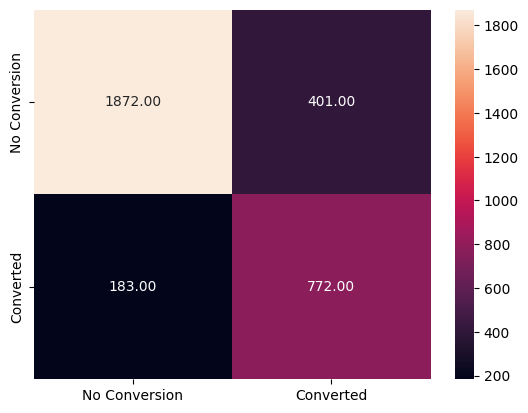

```
Accuracy:0.809

Classification report:
              precision    recall  f1-score   support

           0       0.90      0.82      0.86       962
           1       0.66      0.79      0.72       422

    accuracy                           0.81      1384
   macro avg       0.78      0.80      0.79      1384
weighted avg       0.82      0.81      0.81      1384

Confusion Matrix
[[787 175]
 [ 89 333]]
```

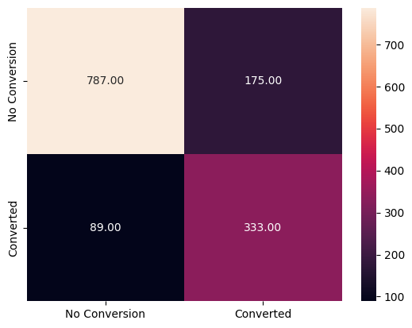

```
***********Model Performance****************
   num               model_name  Precision    Recall  Accuracy  F1_score
1    1  DecisionTree_train_MD_3   0.784545  0.815979  0.819083  0.795314
   num              model_name  Precision    Recall  Accuracy  F1_score
2    2  DecisionTree_test_MD_3   0.776957  0.803593  0.809249  0.786247
```

```python
# Measure the performance of first Decision tree Model
df_perf_dt_a = measure_performance(X_train,y_train,dt,'DecisionTree_train_MD_3',1)
df_perf_dt_b = measure_performance(X_test,y_test,dt,'DecisionTree_test_MD_3',2)
print ("***********Model Performance****************")
print(df_perf_dt_a)
print(df_perf_dt_b)
```

- The decision trees has a**ccuracy of 80.9% and F1 score of 79.5**, both *these metric show drop on test* indicating slight overfitting
- **Recall** on training sample is at good level at **81.5% ** by On **test sample it drops 80.3%**
- **The channel of First interaction, Time Spent on website and Current Occupation status and Profule completion level are top splitters.**

```python
# Building decision tree model using GridSearch
dt_1 = DecisionTreeClassifier(random_state = 1)
param_grid = {'max_depth' : np.arange(2,7,1),
              'criterion': ['gini', 'entropy'],
              'min_samples_leaf' : [5,7,10]  }
#use Grid Search
gridSearch = GridSearchCV(dt_1,param_grid, scoring='recall_weighted',cv=5)
gridSearch.fit(X_train,y_train)

best_params = gridSearch.best_params_
best_recall = gridSearch.best_score_

# print the best parameters for max depth and min number of nodes
print(best_params)
print(best_recall )
```

```
{'criterion': 'entropy', 'max_depth': np.int64(5), 'min_samples_leaf': 7}
0.8640022079823362
```

```python
# Decision tree model based on based parameters identified with GridSearch
dt_1 = DecisionTreeClassifier(random_state = 1, max_depth =best_params['max_depth'], min_samples_leaf = best_params['min_samples_leaf'])
dt_1.fit(X_train, y_train)
```

```
DecisionTreeClassifier(max_depth=np.int64(5), min_samples_leaf=7,
                       random_state=1)
```

```
Accuracy:0.869

Classification report:
              precision    recall  f1-score   support

           0       0.90      0.91      0.91      2273
           1       0.79      0.76      0.77       955

    accuracy                           0.87      3228
   macro avg       0.84      0.84      0.84      3228
weighted avg       0.87      0.87      0.87      3228

Confusion Matrix
[[2077  196]
 [ 227  728]]
```

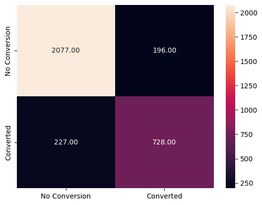

```
Accuracy:0.855

Classification report:
              precision    recall  f1-score   support

           0       0.89      0.91      0.90       962
           1       0.78      0.73      0.75       422

    accuracy                           0.85      1384
   macro avg       0.83      0.82      0.83      1384
weighted avg       0.85      0.85      0.85      1384

Confusion Matrix
[[874  88]
 [113 309]]
```

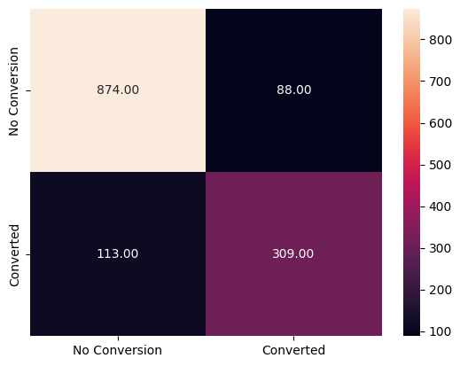

```
************Model Performance****************
   num             model_name  Precision    Recall  Accuracy  F1_score
3    3  DecisionTree_train_GV   0.844677  0.838037  0.868959  0.841231
   num            model_name  Precision    Recall  Accuracy  F1_score
4    4  DecisionTree_test_GV   0.831925  0.820376  0.854769  0.825724
```

```python
# Measure the performance of  Decision tree Model using the

df_perf_dt1_a = measure_performance(X_train,y_train,dt_1,'DecisionTree_train_GV',3)
df_perf_dt1_b = measure_performance(X_test,y_test,dt_1,'DecisionTree_test_GV',4)
print ("************Model Performance****************")
print(df_perf_dt1_a)
print(df_perf_dt1_b)
```

```python
# Third Decision Tree Classifer with pre-prunnning

max_depth_values = np.arange(2,11,3)
max_leaf_nodes_values =  np.arange(3,15,3)
diff_f1_score =float('inf')
best_max_depth = None
best_max_leaf_node = None
for max_depth in max_depth_values :
    for max_leaf_nodes in max_leaf_nodes_values:
        dtree = DecisionTreeClassifier(random_state = 1,max_depth=max_depth,max_leaf_nodes=max_leaf_nodes)
        dtree.fit(X_train,y_train)
        train_f1 = f1_score(y_train,  dtree.predict(X_train),average='macro')
        test_f1 = f1_score(y_test,  dtree.predict(X_test),average='macro')

        if train_f1 > test_f1 :
            current_diff = abs(train_f1 - test_f1)
            if current_diff < diff_f1_score:
                diff_f1_score = current_diff
                best_max_depth = max_depth
                best_max_leaf_node = max_leaf_nodes

# Print best parameters for dept and nodes
print(best_max_depth)
print(best_max_leaf_node)
```

```
8
12
```

```python
# Train decision tree classifier using the parameters identified through prunning
dt_2 = DecisionTreeClassifier(random_state = 1, max_depth =best_max_depth, max_leaf_nodes = best_max_leaf_node)
dt_2.fit(X_train, y_train),
```

```
(DecisionTreeClassifier(max_depth=np.int64(8), max_leaf_nodes=np.int64(12),
                        random_state=1),)
```

```
****Model Performance - Training Sample - Pruning ***************
----------------------------------------------------------------------------------------------------
Accuracy:0.865

Classification report:
              precision    recall  f1-score   support

           0       0.88      0.94      0.91      2273
           1       0.83      0.68      0.75       955

    accuracy                           0.86      3228
   macro avg       0.85      0.81      0.83      3228
weighted avg       0.86      0.86      0.86      3228

Confusion Matrix
[[2142  131]
 [ 305  650]]
```

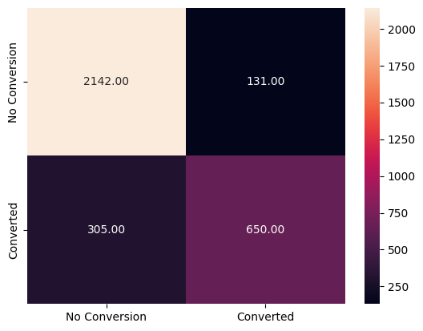

```
****Model Performance - Test Sample - Pruning ***************
----------------------------------------------------------------------------------------------------
Accuracy:0.855

Classification report:
              precision    recall  f1-score   support

           0       0.87      0.94      0.90       962
           1       0.82      0.67      0.74       422

    accuracy                           0.86      1384
   macro avg       0.85      0.80      0.82      1384
weighted avg       0.85      0.86      0.85      1384

Confusion Matrix
[[902  60]
 [140 282]]
```

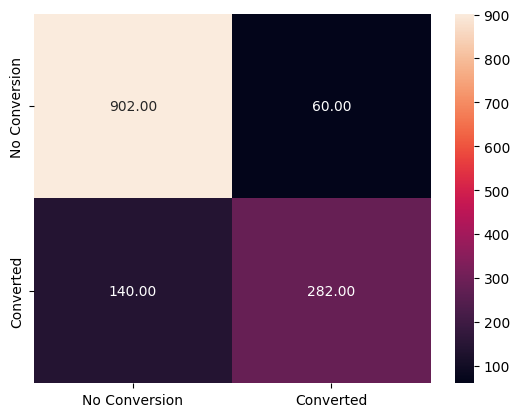

```
************Model Performance****************
   num                model_name  Precision    Recall  Accuracy  F1_score
5    5  DecisionTree_train_Prune   0.853812  0.811498  0.864932  0.828238
   num               model_name  Precision    Recall  Accuracy  F1_score
6    6  DecisionTree_test_Prune   0.845102  0.802938  0.855491   0.81921
```

```python
# Measure the performance of  Decision tree Model with Pruning
print('****Model Performance - Training Sample - Pruning ***************')
print('--'*50)
df_perf_dt2_a = measure_performance(X_train,y_train,dt_2,'DecisionTree_train_Prune',5)
print('****Model Performance - Test Sample - Pruning ***************')
print('--'*50)
df_perf_dt2_b = measure_performance(X_test,y_test,dt_2,'DecisionTree_test_Prune',6)
print ("************Model Performance****************")
print(df_perf_dt2_a)
print(df_perf_dt2_b)
```

- The decision trees has a**ccuracy of 86.4% and F1 score of 82.8**, both *these metric shows drop on test . **The difference between train and test sample is lower than on other 2 decision tree classifiers**
- **Recall** on training sample is at good level at **81.5% ** by On **test sample it drops 80.2%**
- **The channel of First interaction, Time Spent on website and Current Occupation status, last activity type and Profile completion level are top splitters.**

## Model Performance evaluation and improvement

```python
# combined performance from all the decision tree models
df_perf_combd_1 = pd.merge(df_perf_dt_a,df_perf_dt_b,how='outer')

df_perf_combd_2 = pd.merge(df_perf_dt1_a ,df_perf_dt1_b,how='outer')
df_perf_combd_3 = pd.merge(df_perf_dt2_a ,df_perf_dt2_b,how='outer')
df_perf_combd_t = pd.merge(df_perf_combd_1,df_perf_combd_2,how='outer')
df_perf_combd_all = pd.merge(df_perf_combd_t,df_perf_combd_3,how='outer')
df_perf_combd_all
```

|  | num | model_name | Precision | Recall | Accuracy | F1_score |
| --- | --- | --- | --- | --- | --- | --- |
| 0 | 1 | DecisionTree_train_MD_3 | 0.784545 | 0.815979 | 0.819083 | 0.795314 |
| 1 | 2 | DecisionTree_test_MD_3 | 0.776957 | 0.803593 | 0.809249 | 0.786247 |
| 2 | 3 | DecisionTree_train_GV | 0.844677 | 0.838037 | 0.868959 | 0.841231 |
| 3 | 4 | DecisionTree_test_GV | 0.831925 | 0.820376 | 0.854769 | 0.825724 |
| 4 | 5 | DecisionTree_train_Prune | 0.853812 | 0.811498 | 0.864932 | 0.828238 |
| 5 | 6 | DecisionTree_test_Prune | 0.845102 | 0.802938 | 0.855491 | 0.819210 |

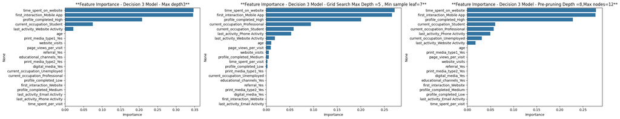

```python
# Decision Tree Model - Feature IMportance comparison
columns = X.columns
importance_dt_md3 = dt.feature_importances_
importance_dt_gv = dt_1.feature_importances_
importance_dt_pr = dt_2.feature_importances_
importance_df_md_3 = pd.DataFrame(importance_dt_md3, index = columns, columns = ['Importance']).sort_values(by = 'Importance', ascending = False)
importance_df_gv = pd.DataFrame(importance_dt_gv, index = columns, columns = ['Importance']).sort_values(by = 'Importance', ascending = False)
importance_df_pr = pd.DataFrame(importance_dt_pr, index = columns, columns = ['Importance']).sort_values(by = 'Importance', ascending = False)
fig, axes = plt.subplots(1, 3, figsize=(25, 5))  # Adjust figsize for better spacing

sns.barplot(x= importance_df_md_3.Importance, y=importance_df_md_3.index,ax=axes[0])
axes[0].set_title('**Feature Importance - Decision 3 Model - Max depth3**')
sns.barplot(x=importance_df_gv.Importance,y=importance_df_gv.index,ax=axes[1])
axes[1].set_title('**Feature Importance - Decision 3 Model - Grid Search Max Depth =5 , Min sample leaf=7**')
sns.barplot(x=importance_df_pr.Importance,y=importance_df_pr.index,ax=axes[2])
axes[2].set_title('**Feature Importance - Decision 3 Model - Pre-pruning Depth =8,Max nodes=12**')
plt.tight_layout()
plt.show()
```

## Building a Random Forest model

**Random Forest classifier**

```python
# Base RandomForestClassifier

rf_estimator = RandomForestClassifier( random_state = 1)

rf_estimator.fit(X_train, y_train)
```

```
RandomForestClassifier(random_state=1)
```

## Model Performance evaluation and improvement

```
Accuracy:1.000

Classification report:
              precision    recall  f1-score   support

           0       1.00      1.00      1.00      2273
           1       1.00      1.00      1.00       955

    accuracy                           1.00      3228
   macro avg       1.00      1.00      1.00      3228
weighted avg       1.00      1.00      1.00      3228

Confusion Matrix
[[2273    0]
 [   0  955]]
```

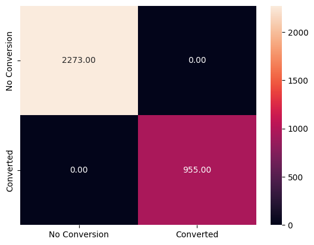

```
Accuracy:0.854

Classification report:
              precision    recall  f1-score   support

           0       0.88      0.92      0.90       962
           1       0.79      0.70      0.75       422

    accuracy                           0.85      1384
   macro avg       0.84      0.81      0.82      1384
weighted avg       0.85      0.85      0.85      1384

Confusion Matrix
[[885  77]
 [125 297]]
```

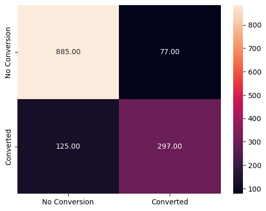

```
************Model Performance****************
   num          model_name  Precision  Recall  Accuracy  F1_score
7    7  randomForest_train        1.0     1.0       1.0       1.0
   num         model_name  Precision    Recall  Accuracy  F1_score
8    8  randomForest_test   0.835178  0.811875  0.854046  0.821899
```

```python
# Model Performance evaluation - Base random forest classifier
df_perf_rf1_a = measure_performance(X_train,y_train,rf_estimator,'randomForest_train',7)
df_perf_rf1_b = measure_performance(X_test,y_test,rf_estimator,'randomForest_test',8)
print ("************Model Performance****************")
print(df_perf_rf1_a)
print(df_perf_rf1_b)
```

**Observations:**

**The Random Forest classifier seems to be overfitting the training data.**

The recall on the training data is 1, while the recall on the test data is only ~ 0.80

Precision is high on training but drops on test dataset

**Random Forest classifer with Hyperparameter tuning**

```python
# Random Forest classifer initialization for hyperparameter tuning
rf_estimator_tuned = RandomForestClassifier(random_state = 1)

# Grid of parameters to choose from
params_rf = {
        "n_estimators": [10,15,18,22],
        "min_samples_leaf": np.arange(5,15, 2),
        "max_features": [0.4, 0.7,0.9, 'auto'],
}

import sklearn.metrics as metrics
# Type of scoring used to compare parameter combinations - recall score for class 1
scorer = metrics.make_scorer(recall_score, pos_label = 1)

# Run the grid search
grid_obj = GridSearchCV(rf_estimator_tuned, params_rf, scoring = scorer, cv = 5)

grid_obj = grid_obj.fit(X_train, y_train)

# Set the classifier to the best combination of parameters
rf_estimator_tuned = grid_obj.best_estimator_
print(grid_obj.best_params_)
```

```
{'max_features': 0.7, 'min_samples_leaf': np.int64(5), 'n_estimators': 22}
```

```python
# Random Tree classifer with best parameters identified through GridSearch
rf_estimator_tuned = RandomForestClassifier(random_state = 1,n_estimators=grid_obj.best_params_['n_estimators'],min_samples_leaf=grid_obj.best_params_['min_samples_leaf'],max_features=grid_obj.best_params_['max_features'])
rf_estimator_tuned.fit(X_train, y_train)
```

```
RandomForestClassifier(max_features=0.7, min_samples_leaf=np.int64(5),
                       n_estimators=22, random_state=1)
```

```
Accuracy:0.917

Classification report:
              precision    recall  f1-score   support

           0       0.93      0.96      0.94      2273
           1       0.89      0.82      0.85       955

    accuracy                           0.92      3228
   macro avg       0.91      0.89      0.90      3228
weighted avg       0.92      0.92      0.92      3228

Confusion Matrix
[[2181   92]
 [ 176  779]]
```

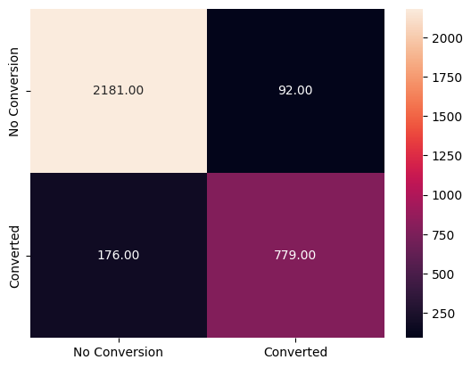

```
Accuracy:0.861

Classification report:
              precision    recall  f1-score   support

           0       0.88      0.93      0.90       962
           1       0.81      0.71      0.76       422

    accuracy                           0.86      1384
   macro avg       0.85      0.82      0.83      1384
weighted avg       0.86      0.86      0.86      1384

Confusion Matrix
[[892  70]
 [122 300]]
```

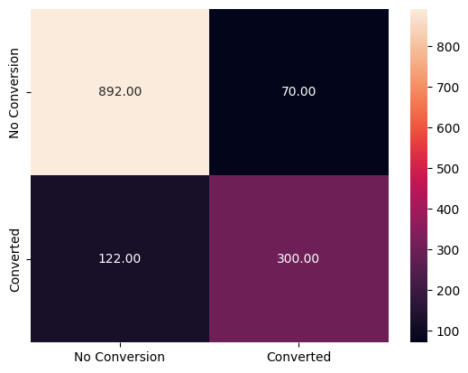

```
************Model Performance****************
   num               model_name  Precision    Recall  Accuracy  F1_score
9    9  randomForest_train_w_GV   0.909852  0.887616  0.916976  0.897674
    num            model_name  Precision    Recall  Accuracy  F1_score
10   10  randomForest_test_GV   0.845248  0.819068  0.861272  0.830205
```

```python
# Random Tree classifer with best parameters - Model performance evaluation
df_perf_rf2_a = measure_performance(X_train,y_train,rf_estimator_tuned,'randomForest_train_w_GV',9)
df_perf_rf2_b = measure_performance(X_test,y_test,rf_estimator_tuned,'randomForest_test_GV',10)
print ("************Model Performance****************")
print(df_perf_rf2_a)
print(df_perf_rf2_b)
```

**The Random Forest classifier based on best parameters post-tuning also seems to be overfitting the training data.**

The recall on the training data dropped to ~89%, while the recall on the test data is only ~ 82%

Precision is high on training but drops on test dataset

## Model Performance evaluation and improvement

**Comparing RandomForest Classifier vs. Decision tree Classifer performance**

```python
# combined performance from Random Forest classifier results
df_perf_rf_1 = pd.merge(df_perf_rf1_a,df_perf_rf1_b,how='outer')
df_perf_rf_2 = pd.merge(df_perf_rf2_a,df_perf_rf2_b,how='outer')
df_perf_combd_rf_all = pd.merge(df_perf_rf_1,df_perf_rf_2,how='outer')
# combining Decision tree and Random forest classifier results

df_perf_combd_dt_rf = pd.merge(df_perf_combd_all,df_perf_combd_rf_all,how='outer')
df_perf_combd_dt_rf
```

|  | num | model_name | Precision | Recall | Accuracy | F1_score |
| --- | --- | --- | --- | --- | --- | --- |
| 0 | 1 | DecisionTree_train_MD_3 | 0.784545 | 0.815979 | 0.819083 | 0.795314 |
| 1 | 2 | DecisionTree_test_MD_3 | 0.776957 | 0.803593 | 0.809249 | 0.786247 |
| 2 | 3 | DecisionTree_train_GV | 0.844677 | 0.838037 | 0.868959 | 0.841231 |
| 3 | 4 | DecisionTree_test_GV | 0.831925 | 0.820376 | 0.854769 | 0.825724 |
| 4 | 5 | DecisionTree_train_Prune | 0.853812 | 0.811498 | 0.864932 | 0.828238 |
| 5 | 6 | DecisionTree_test_Prune | 0.845102 | 0.802938 | 0.855491 | 0.819210 |
| 6 | 7 | randomForest_train | 1.000000 | 1.000000 | 1.000000 | 1.000000 |
| 7 | 8 | randomForest_test | 0.835178 | 0.811875 | 0.854046 | 0.821899 |
| 8 | 9 | randomForest_train_w_GV | 0.909852 | 0.887616 | 0.916976 | 0.897674 |
| 9 | 10 | randomForest_test_GV | 0.845248 | 0.819068 | 0.861272 | 0.830205 |

**Observations**

- The performance of Decision tree base model and post-pruning have recall ~81%. - With GridSearch the recall improves to 84%.
- With Random Forest based models recall increases to 880+% but these seem to be overfitting on training sample.
- **The Decision tree model with Pruning has recall of 81% and , F1 score of 82.5% and accuracy of ~86%. It also validates well on the test data with recall remaining at 81%.**

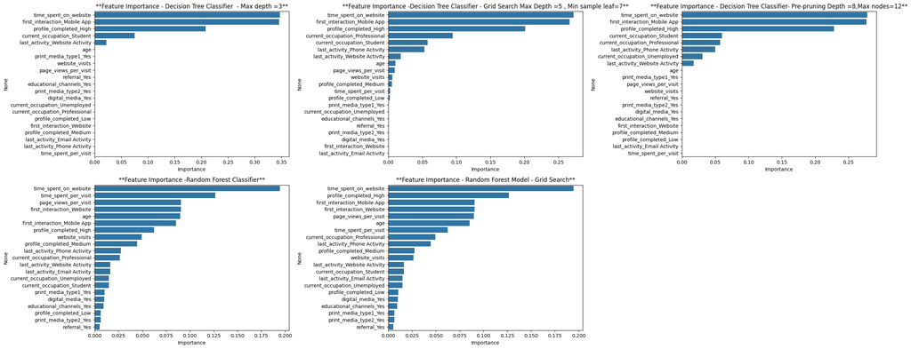

```python
# Random Forest Classifier - Feature Importance
importances_rf = rf_estimator.feature_importances_
importance_df_rf = pd.DataFrame(importances_rf, index = columns, columns = ['Importance']).sort_values(by = 'Importance', ascending = False)


# Random Forest Classifier with Tuning - Feature Importance
importances_rf2 = rf_estimator_tuned.feature_importances_
importance_df_rf2 = pd.DataFrame(importances_rf2, index = columns, columns = ['Importance']).sort_values(by = 'Importance', ascending = False)


# Importance Features from each of Decision Tree and Random Forest Classifier

fig, axes = plt.subplots(2, 3, figsize=(25, 10))  # Adjust figsize for better spacing

sns.barplot(x= importance_df_md_3.Importance, y=importance_df_md_3.index,ax=axes[0,0])
axes[0,0].set_title('**Feature Importance - Decision Tree Classifier  - Max depth =3**')
sns.barplot(x=importance_df_gv.Importance,y=importance_df_gv.index,ax=axes[0,1])
axes[0,1].set_title('**Feature Importance -Decision Tree Classifier - Grid Search Max Depth =5 , Min sample leaf=7**')
sns.barplot(x=importance_df_pr.Importance,y=importance_df_pr.index,ax=axes[0,2])
axes[0,2].set_title('**Feature Importance - Decision Tree Classifier- Pre-pruning Depth =8,Max nodes=12**')
sns.barplot(x= importance_df_rf.Importance, y=importance_df_rf.index,ax=axes[1,0])
axes[1,0].set_title('**Feature Importance -Random Forest Classifier**')
sns.barplot(x= importance_df_rf.Importance, y=importance_df_rf2.index,ax=axes[1,1]);
axes[1,1].set_title('**Feature Importance - Random Forest Model - Grid Search**')
axes[1,2].axis('off')


plt.tight_layout()
plt.show()
```

**Observations:**

```python
# Plot decision tree developed using pre-pruning for Profile of customer likely to convert to paid membership
plt.figure(figsize=(25,10))

plot_tree(dt_2,feature_names=X_train.columns,filled=True,fontsize=12)
plt.tight_layout()
plt.show()
```

[output not shown]

**Observations:**

# **Conclusion:**

-**ExtraaLearn should use this model to identify which customers are most likely to convert to paid membership**

# **Actionable Insights and Recommendations**

**Model Use**

**Model Monitoring**

Given the custom leads web activity and interaction, ExtraaLearn needs to regularly monitor model performance results for effectiveness. It is highly recommended, ExtraaLearn look at scoring the customer leads on regular duration ( 3-5 days) and update/refresh model based on changes in behavior.

```python
! jupyter nbconvert --to html  '/content/drive/My Drive/GL_MIT_ADSP/Week_8_Elective/ChetanaShah_Full_Code_Version_PotentialCustomersPrediction.ipynb'
```